# Suite de l’analyse descriptive du jeu de données SIWIM

# Introduction

Nous poursuivons dans cette section notre analyse descriptive du jeu de données par une étude bi-dimensionnelle des variables qualitatives et quantitatives.

Nous compléterons avec quelques indicateurs quantitatifs et graphiques.

Enfin, nous utiliserons des techniques d’analyses multidimensionnelles : les analyses factorielles et le clustering non supervisé afin de poursuivre l’exploration de notre jeu de données.

```r
# chargement des librairies

library(data.table)
library(questionr)  # calcul Vcramer et des fréquences
library(ggplot2)
library(corrplot)   # affichage matrice des correlations
library(FactoMineR) # analyses factorielles
library(factoextra) # beaux graphiques pour analyses factorielles et clustering
library(fastcluster) # clustering CAH rapide
library(cluster)     # clustering CLARA
library(dbscan)
```

Nous choisissons de poursuivre nos analyses sur la base du jeu de données dont les données manquantes ont été imputées :

```r
# Chargement
siwim_imputed <- read.csv("2_Data/2_Retraitees/SiWIM_data_after_input.csv")
#siwim_imputed <- read.csv("2_Data/2_Retraitees/SiWIM_data_missing_deleted.csv")

# Structure du fichier
str(siwim_imputed)
```

```
## 'data.frame':    183928 obs. of  39 variables:
##  $ X                  : int  1 2 3 4 5 6 7 8 9 10 ...
##  $ Timestamp          : Factor w/ 182402 levels "2017-07-05 00:08:33",..: 180458 180459 180460 180461 180462 180463 180464 180465 180466 180467 ...
##  $ Site_ID            : Factor w/ 1 level "Normandie": 1 1 1 1 1 1 1 1 1 1 ...
##  $ Warning_flags      : Factor w/ 32 levels "00000000","00000001",..: 1 1 1 1 1 1 1 1 1 1 ...
##  $ Subclass_ID        : int  113 40 20 113 113 74 113 91 113 113 ...
##  $ Axle_groups        : num  113 11 11 113 113 ...
##  $ A1                 : num  3.9 3.54 2.37 3.8 3.72 ...
##  $ A2                 : num  5.68 NA NA 5.92 5.68 ...
##  $ A3                 : num  1.33 NA NA 1.28 1.33 ...
##  $ A4                 : num  1.33 NA NA 1.37 1.33 ...
##  $ A5                 : num  NA NA NA NA NA ...
##  $ A6                 : num  NA NA NA NA NA NA NA NA NA NA ...
##  $ A7                 : num  NA NA NA NA NA NA NA NA NA NA ...
##  $ Date               : Factor w/ 122 levels "2017-07-05","2017-07-06",..: 122 122 122 122 122 122 122 122 122 122 ...
```

[output cut: 25 more lines]

```r
# Transformation en data table
setDT(siwim_imputed)
```

On effectue quelques conversions post import des données :

```r
# Conversion en factor de Subclass_ID
siwim_imputed[, Subclass_ID := factor(as.character(Subclass_ID))]

# Conversion en factor de la variable Axle_groups
siwim_imputed[, Axle_groups := factor(as.character(Axle_groups))]

# Conversion en factor de la variable Nb_Axles (nombre d'axes)
siwim_imputed[, Nb_axles := as.factor(as.character(Nb_axles))]

# Conversion en factor de la variable Annee
siwim_imputed[, Annee := factor(as.character(Annee))]

# Conversion en factor de la variable Mois_num
siwim_imputed[, Mois_num := factor(as.character(Mois_num))]

# Conversion en factor de la variable Jour_num
siwim_imputed[, Jour_num := factor(as.character(Jour_num))]

# Conversion en factor de la variable Heure
siwim_imputed[, Heure := factor(Heure)]

# Structure apres conversions
str(siwim_imputed)
```

```
## Classes 'data.table' and 'data.frame':   183928 obs. of  39 variables:
##  $ X                  : int  1 2 3 4 5 6 7 8 9 10 ...
##  $ Timestamp          : Factor w/ 182402 levels "2017-07-05 00:08:33",..: 180458 180459 180460 180461 180462 180463 180464 180465 180466 180467 ...
##  $ Site_ID            : Factor w/ 1 level "Normandie": 1 1 1 1 1 1 1 1 1 1 ...
##  $ Warning_flags      : Factor w/ 32 levels "00000000","00000001",..: 1 1 1 1 1 1 1 1 1 1 ...
##  $ Subclass_ID        : Factor w/ 72 levels "10","100","101",..: 9 32 25 9 9 52 9 65 9 9 ...
##  $ Axle_groups        : Factor w/ 2211 levels "11","111","1111",..: 607 1 1 607 607 607 607 859 607 607 ...
##  $ A1                 : num  3.9 3.54 2.37 3.8 3.72 ...
##  $ A2                 : num  5.68 NA NA 5.92 5.68 ...
##  $ A3                 : num  1.33 NA NA 1.28 1.33 ...
##  $ A4                 : num  1.33 NA NA 1.37 1.33 ...
##  $ A5                 : num  NA NA NA NA NA ...
##  $ A6                 : num  NA NA NA NA NA NA NA NA NA NA ...
##  $ A7                 : num  NA NA NA NA NA NA NA NA NA NA ...
##  $ Date               : Factor w/ 122 levels "2017-07-05","2017-07-06",..: 122 122 122 122 122 122 122 122 122 122 ...
```

[output cut: 26 more lines]

Nous recréons deux jeux de données séparant variables quantitatives et qualitatives :

```r
varquanti <- siwim_imputed[, lapply(siwim_imputed, is.numeric) == TRUE, with = FALSE]
varquali <- siwim_imputed[,lapply(siwim_imputed,is.numeric) == FALSE, with = FALSE]
```

# Retour sur variables quanti (post - imputation)

Nous construisons quelques boxplot, des variables quantitatives les plus intéressantes, après avoir imputer les données.

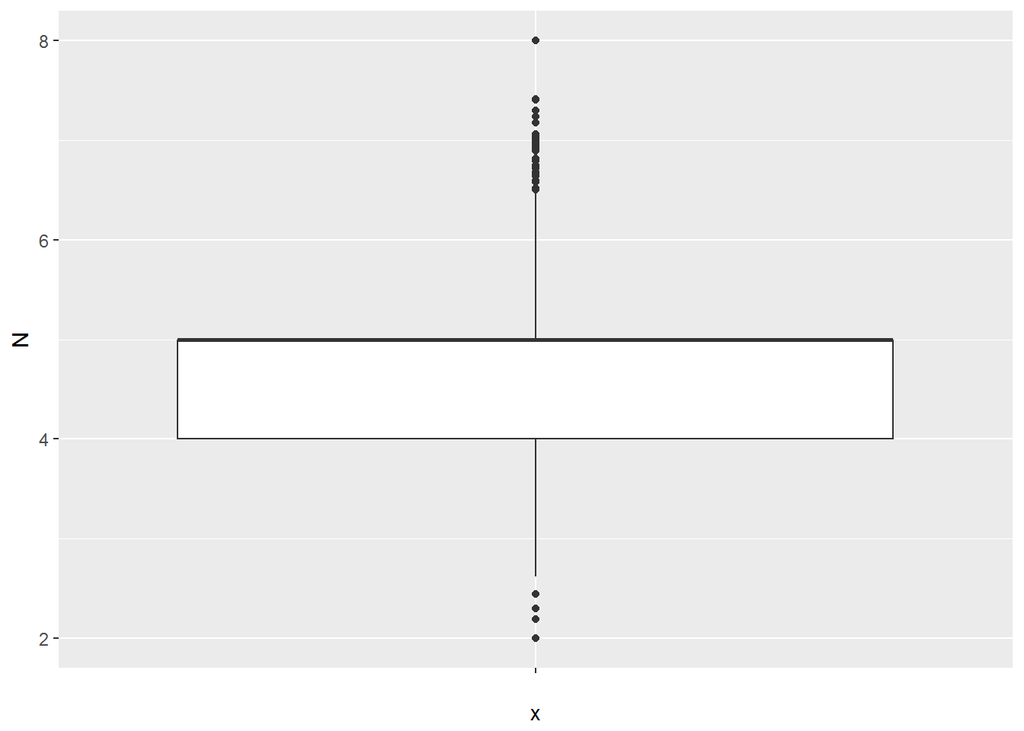

```r
# Nombre d'essieux
ggplot(varquanti,aes("", y = N)) + geom_boxplot()
```

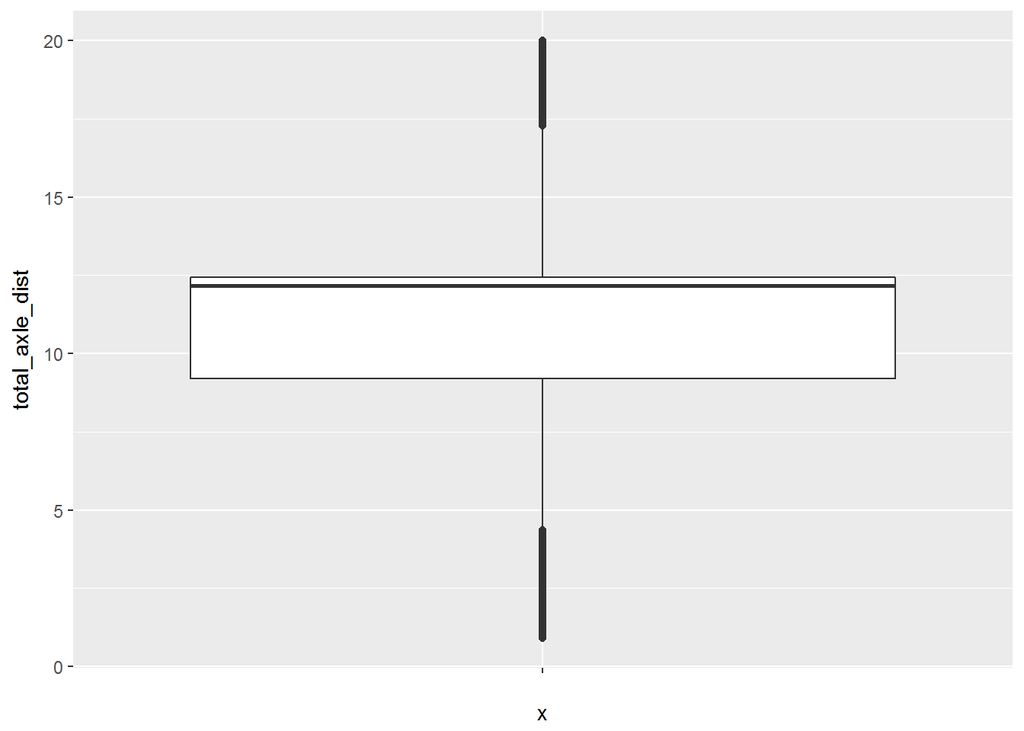

```r
# Distance totale entre les essieux les plus éloignés
ggplot(varquanti,aes("", y = total_axle_dist)) + geom_boxplot()
```

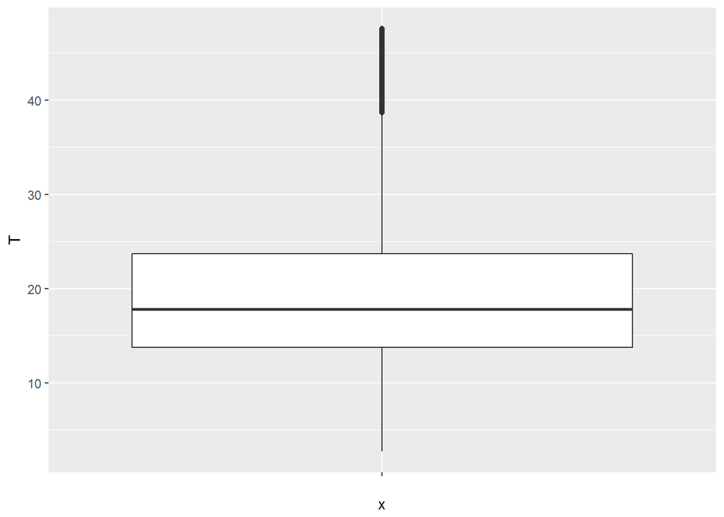

```r
# Temperature utilisée par la compensation
ggplot(varquanti,aes("", y = T)) + geom_boxplot()
```

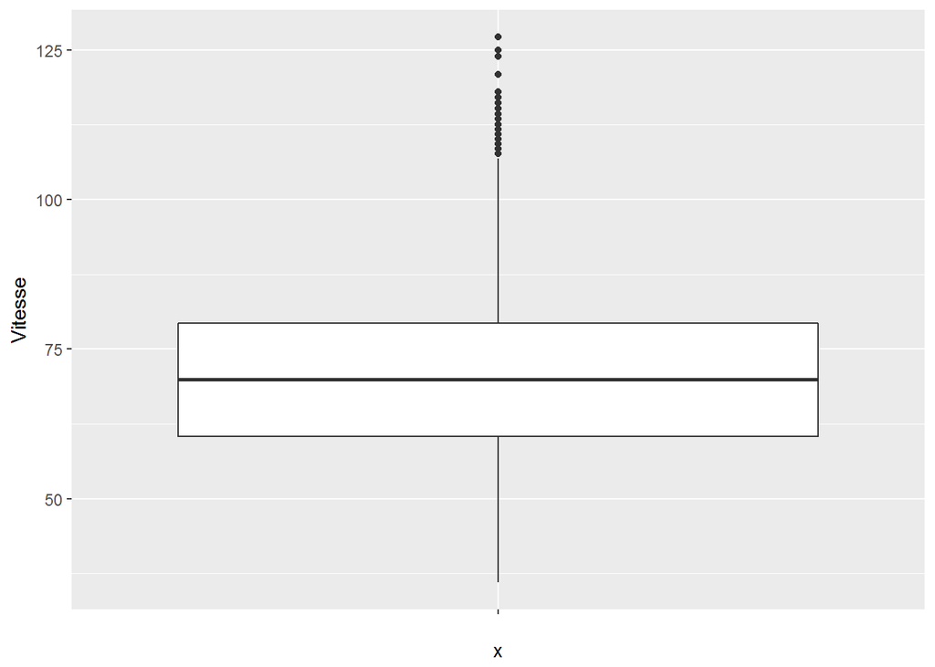

```r
# Vitesse
ggplot(varquanti,aes("", y = Vitesse)) + geom_boxplot()
```

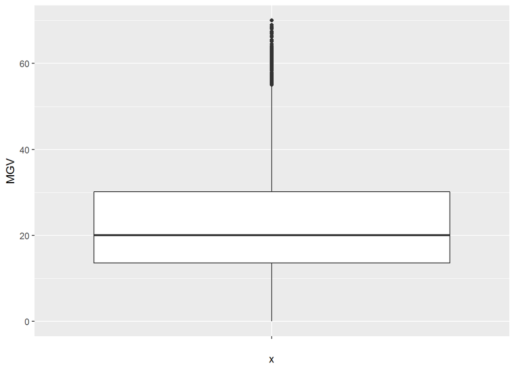

```r
# Masse du camion
ggplot(varquanti,aes("", y = MGV)) + geom_boxplot()
```

# Analyse bi dimensionnelle (étude des liaisons)

### Etude des liaisons entre variables qualitatives

```r
# Croisement heure  et jour de passage
table(varquali$Jour_semaine,varquali$Heure)
```

```
##
##               0    1    2    3    4    5    6    7    8    9   10   11
##   dimanche   30   25   19   17   27   11   56   49   81  153  214  259
##   jeudi     203  149  211  346  451  828 1673 2761 2714 2675 2753 2467
##   lundi      83  127  144  210  273  666 1136 2034 2252 2402 2537 2404
##   mardi     156  154  200  270  387  716 1459 2409 2302 2304 2474 2288
##   mercredi  179  196  246  345  440  896 1672 2662 2600 2779 2699 2694
##   samedi    124  122  143  235  243  257  273  350  323  374  382  334
##   vendredi  188  168  222  313  444  860 1544 2488 2405 2485 2343 2201
##
##              12   13   14   15   16   17   18   19   20   21   22   23
##   dimanche  234  252  304  247  240  308  275  193  182  115   76   65
##   jeudi    2463 2598 2992 3080 2943 2351 1801 1129  764  492  315  184
##   lundi    2379 2404 2706 2646 2351 1821 1380  982  597  446  277  220
##   mardi    2273 2480 2804 2839 2711 2389 1701 1144  667  395  311  192
##   mercredi 2763 2800 3123 3234 2864 2497 1744 1213  683  418  293  247
##   samedi    345  299  254  268  232  221  235  118   98   63   36   30
##   vendredi 2094 2236 2249 2241 1755 1282  930  599  380  258  182  138
```

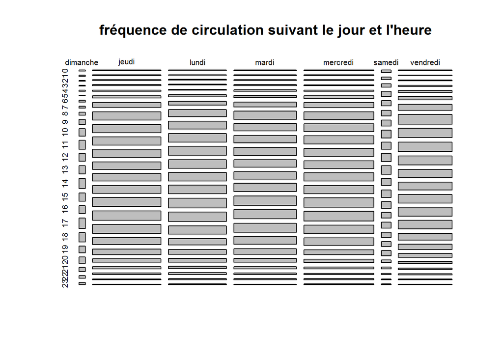

```r
plot(table(varquali$Jour_semaine,varquali$Heure),main = "fréquence de circulation suivant le jour et l'heure")
```

Les camions circulent peu le Samedi et le Dimanche et nettement moins la nuit.

```r
# On travaille avec un sous ensemble utiles des variables qualitatives
varquali2 <- varquali[,.(Warning_flags,Subclass_ID,Axle_groups,Mois_annee,Jour_semaine,Heure,Lane,Nb_axles,Anomalie)]
varquali2 <- as.data.frame(varquali2)
```

Nous allons à présent étudier la force de la liaison entre les variables qualitatives, et pour cela, calculer le V de Cramer. Le V de Cramer présente l’avantage d’offrir une mesure absolue de l’intensité de la liaison entre deux variables qualitatives. La liaison est nulle quand V =0, liaison est maximales lorsque V = 1.

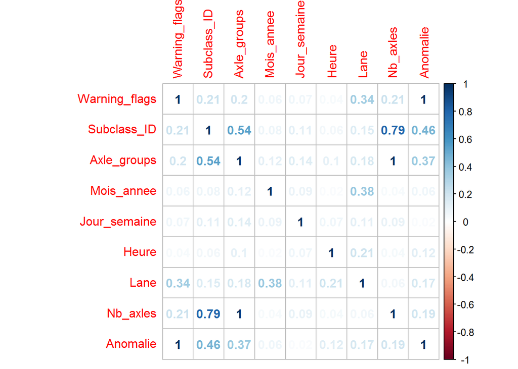

```r
# liaisons entre variables qualitatives (calcul du V de Cramer)
cramer <- matrix(NA, ncol(varquali2), ncol(varquali2))
for (i in (1:ncol(varquali2))){
  for (j in (1:ncol(varquali2))){
    cramer[i,j] <- cramer.v(table(varquali2[,i], varquali2[,j]))
  }
}

colnames(cramer) <- colnames(varquali2)
rownames(cramer) <- colnames(varquali2)

corrplot(cramer, method="number")
```

Il semble y avoir un lien entre le fait de rouler à gauche ou à droite (`lane`) et le mois de circulation. Attention car les données ont été récupérées sur un nombre de mois limités (ici 5 mois). Il semble également y avoir un lien entre l’heure de circulation et le fait de rouler à gauche ou à droite. Mais ce lien est plutôt faible.

Le Vcramer est important entre la classification réalisée par le système `SubClasss_ID` et le groupe d’essieux `Axle_Group` ce qui parait logique. Le nombre d’axes `Nb_Axles` est lié totalement au groupe d’essieux`Axles_groups`.

Il semble également y avoir un lien entre le déclenchement d’une anomalie `Anomalie` et la classification réalisée par le système : des groupes de camions sont-ils plus sujets à déclencher des anomalies ?

### Etude des liaisons entre variables quantitatives

```r
# On travaille avec un sous ensemble utiles des variables quantitatives
varquanti2 <- varquanti[,c("N", "total_axle_dist","T","Reduced_chi_squared","Time_num","Vitesse","MGV")]
```

Nous calculons le coefficient de corrélation linéaire de Pearson entre les variables quantitatives :

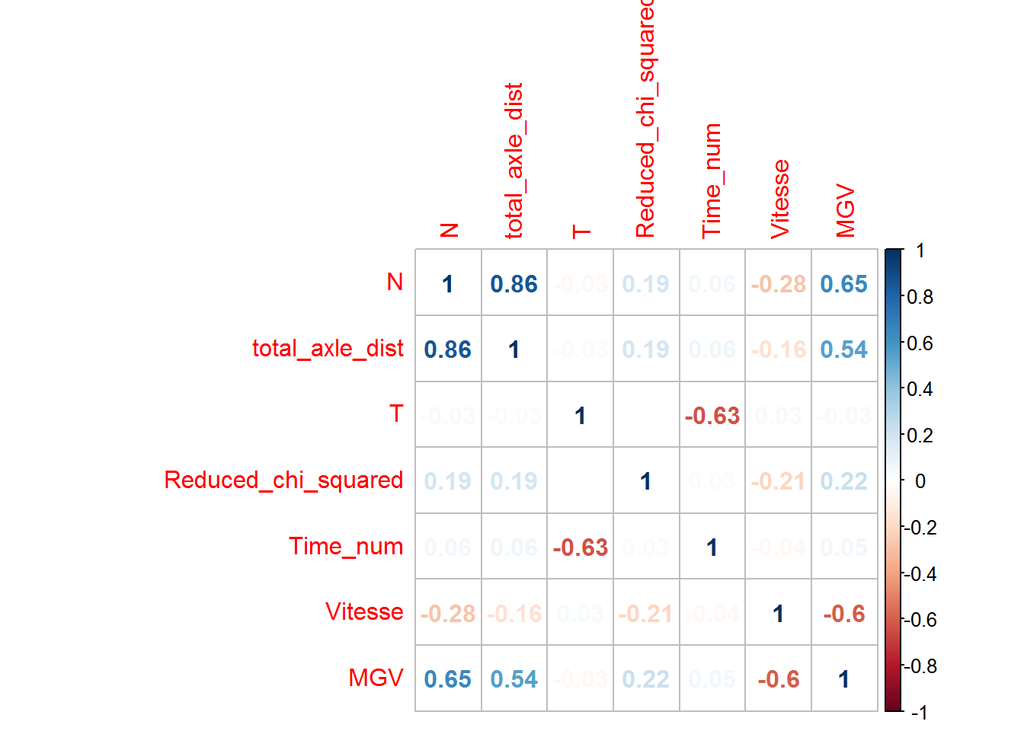

```r
# Matrice de correlation (Pearson)
corr <- cor(varquanti2)
corrplot(corr, method="number")
```

Nous observons ainsi plusieurs relations linéaires entre les données physiques. Ainsi il apparait qu’un camion massique roulera moins vite, qu’il est plus long et a plus d’essieux. Enfin, il apparait logique que la température du système `T` soit fortement corrélée négativement à la variable temporelle `Time_num` car les données ont été récupérées de l’été 2017 à novembre 2017.

On constitue le jeu de données finales, se composant des variables quantitatives et qualitatives utiles :

```r
# Jeu de donnée final
siwim_final <-cbind(varquali2,varquanti2)

# Transformation en data table
setDT(siwim_final)
```

Intéressons nous aux variables quantitatives et analysons graphiquement leur liaison avec la variable qualitative `Anomalie`:

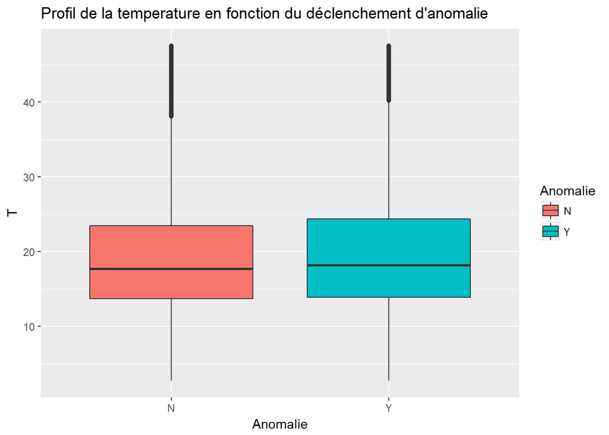

```r
# Température / Ano
ggplot(siwim_final, aes(Anomalie, y=T, group=Anomalie)) +
geom_boxplot(aes(fill=Anomalie))+
ggtitle("Profil de la temperature en fonction du déclenchement d'anomalie")
```

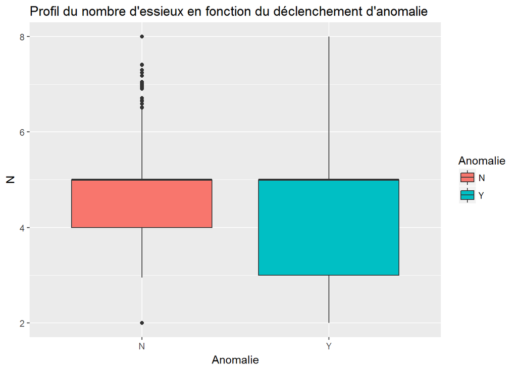

```r
# Nb d'essieux / Ano
ggplot(siwim_final, aes(Anomalie, y=N, group=Anomalie)) +
geom_boxplot(aes(fill=Anomalie))+
ggtitle("Profil du nombre d'essieux en fonction du déclenchement d'anomalie")
```

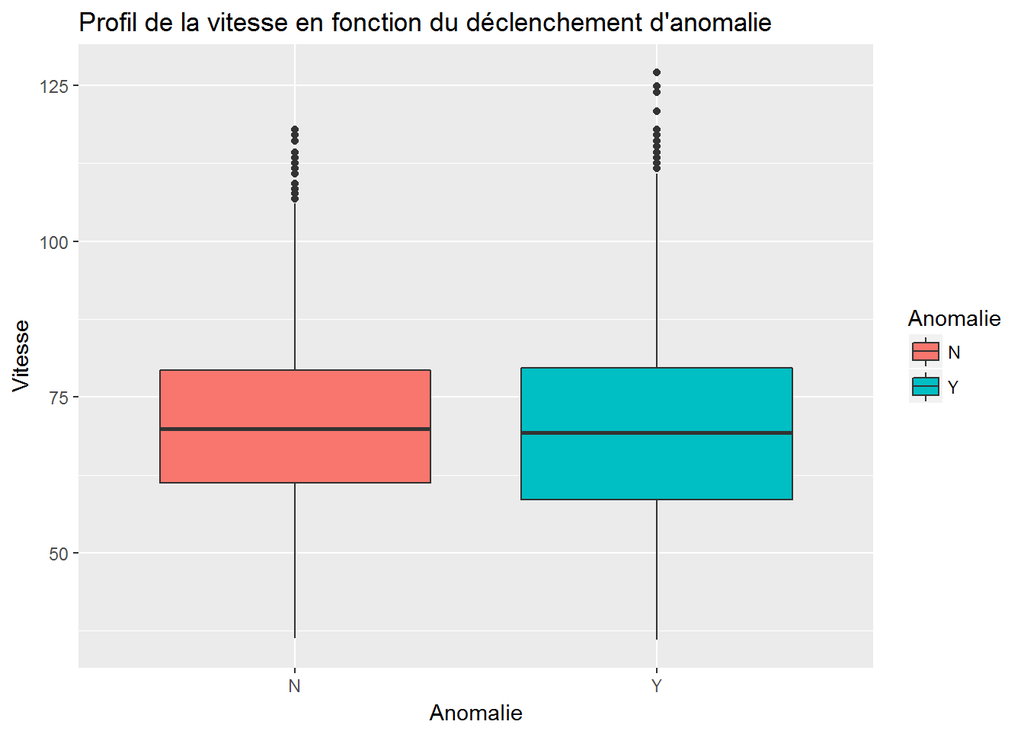

```r
# Vitesse / Ano
ggplot(siwim_final, aes(Anomalie, y=Vitesse, group=Anomalie)) +
geom_boxplot(aes(fill=Anomalie))+
ggtitle("Profil de la vitesse en fonction du déclenchement d'anomalie")
```

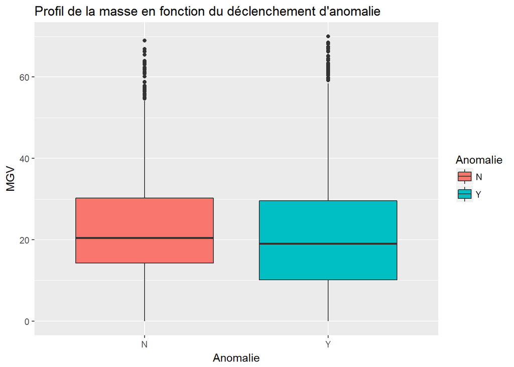

```r
# Masse / Ano
ggplot(siwim_final, aes(Anomalie, y=MGV, group=Anomalie)) +
geom_boxplot(aes(fill=Anomalie))+
ggtitle("Profil de la masse en fonction du déclenchement d'anomalie")
```

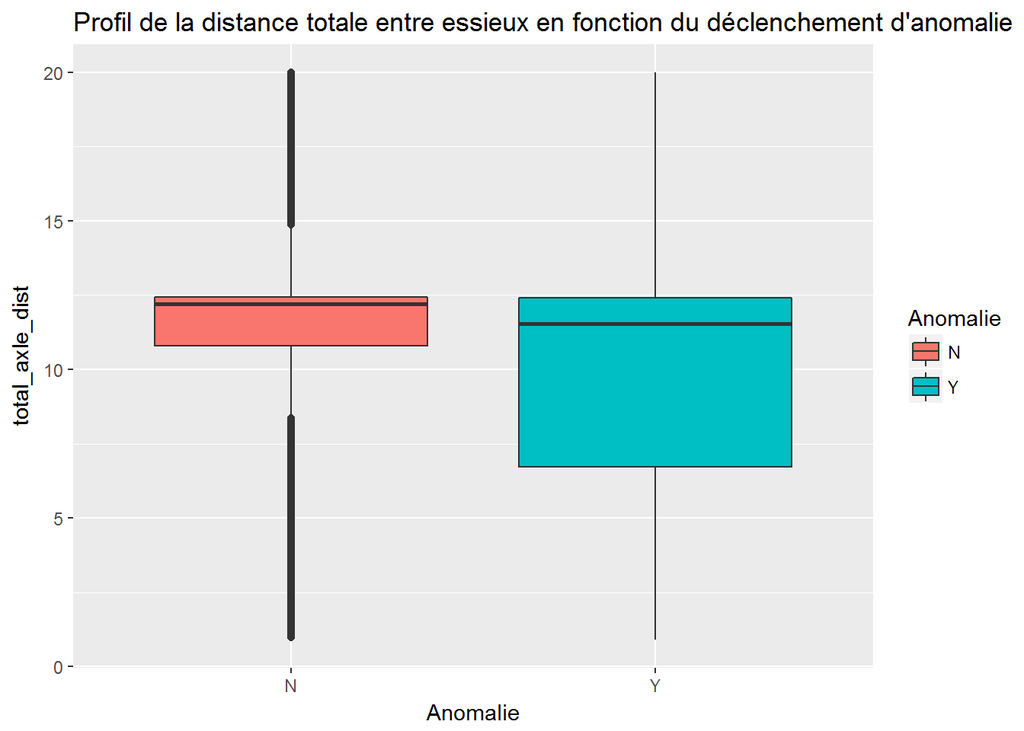

```r
# Distance totale entre les essieux / Ano
ggplot(siwim_final, aes(Anomalie, y=total_axle_dist, group=Anomalie)) +
geom_boxplot(aes(fill=Anomalie))+
ggtitle("Profil de la distance totale entre essieux en fonction du déclenchement d'anomalie")
```

Il est difficile de tirer des conclusions à travers ces graphiques.

Nous envisageons de réaliser des analyses multidimentionnelles qui permettront de résumer les informations et les relations entre les variables.

# Analyse Factorielles

Les analyses factorielles permettent de résumer l’information contenues dans nos données.

L’analyse en composante principale permet de résumer l’information conjointe entre des données quantitatives, en captant les relations linéaires entre les variables.

L’analyse des correspondances multiples, permet quant à elle de résumer l’information entre variables qualitatives.

Nous décidons ici d’utiliser le package `FactoMineR` et d’utiliser la méthode `AFDM (Analyse Factorielle des Donnée Mixtes)`, en anglais FAMD (Factor Analysis for Mixed Data), dont l’intéret est de construire un nouveau système de représentation (facteurs, axes factorielles : combinaisons linéaires des variables quantitatives et des indicatrices des variables qualitatives) qui permet de synthétiser l’information.

Nous souhaitons avoir les réponses aux questions suivantes :

- Quels sont les camions qui se ressemblent (proximité entre les individus) ?
- Sur quelles caractéristiques sont fondées les ressemblances / dissemblances ?
- Quelles sont les relations entre les variables ?
- Quelles sont les relations entres les modalités et les variables quantitatives ?

## Analyse Factorielle des Donnees Mixes (AFDM)

```r
# Calcul de l'AFDM
res_FAMD <-FAMD(siwim_final[,-c(1:3)], graph = FALSE,ncp = 5)
```

Etudions la variance (inertie) expliquée par les axes de l’analyse factorielle :

```r
eig_val <- get_eigenvalue(res_FAMD)
head(eig_val)
```

```
##       eigenvalue variance.percent cumulative.variance.percent
## Dim.1   3.659392         7.623733                    7.623733
## Dim.2   2.667317         5.556910                   13.180643
## Dim.3   1.489196         3.102491                   16.283134
## Dim.4   1.357433         2.827984                   19.111118
## Dim.5   1.272952         2.651982                   21.763101
```

Le premier plan factoriel explique 13% de l’inertie totale. Cela signifie que 13% de l’information du nuage est expliquée par cet axe. **Cela est relativement faible**.

Les 5 premiers axes exliquent quant à eux seulement 22 % de l’inertie totale, ce qui est insuffisant pour une réduction de dimenssionnalité à utiliser en entrée d’un traitement ultérieur.

Le but recherché est de trouver une représentation synthétique des donnée, afin de notamment caractériser des groupes de camions par clustering s’appuyant sur cette représentation.

Les variables qualitatives sont essentiellement des variables de contexte (heure, jour, mois de passage, ainsi que la variable `Anomalie` déclenchée par le système de pesage.) Les variables quantitatives sont essentiellement des descripteurs des camions.

Nous proposons donc d’appliquer une Analyse en Composantes Principales sur les données quantitatives avec les **variables qualitatives en illustration**. Ces variables qualitatives ne participeront pas à la construction des axes, mais en faciliteront leur description.

## Analyse en Composantes Principales (ACP)

```r
# Preparation du jeu de donnee
don_PCA <- cbind.data.frame(varquanti2,varquali2[,c("Mois_annee","Jour_semaine","Heure","Lane","Anomalie")])
```

L’ACP normée (sur données centrées-réduites) est calculée en précisant les variables qualitatives en supplémentaires :

```r
# Calcul de l'ACP avec variables qualitatives supplementaires
res_PCA <-PCA(don_PCA, scale.unit = TRUE, graph = FALSE,ncp = Inf, quali.sup = 8:12)
```

### Variance / Inertie Expliquee

Etudions la variance (inertie) expliquée par les axes de l’analyse factorielle :

```r
eig_val <- get_eigenvalue(res_PCA)
head(eig_val)
```

```
##       eigenvalue variance.percent cumulative.variance.percent
## Dim.1  2.7027040        38.610057                    38.61006
## Dim.2  1.6170737        23.101053                    61.71111
## Dim.3  1.0460832        14.944045                    76.65515
## Dim.4  0.8659142        12.370202                    89.02536
## Dim.5  0.3686499         5.266428                    94.29179
## Dim.6  0.2699959         3.857085                    98.14887
```

Les 7 premières composantes principales capturent 100% de l’inertie (variabilité) du nuage de point initial les 4 premières 89% et les 5 premières 94%. Nous proposerons plus loin de conserver un sous-ensemble d’axes capturant l’essentiel de la variabilité et réduisant le nuage de points initial en évitant d’utiliser des axes supplémentaires qui seront assimilés à du bruit. Nous rappelons que l’ACP “capture” ou met en évidence les relations linéaires entre les variables. Nous sommes conscients que les relations non linéaires entre les variables ne seront ici pas mises en évidence.

Une méthode couramment utilisée est celle consistant à afficher le graphique du coude (scree plot) :

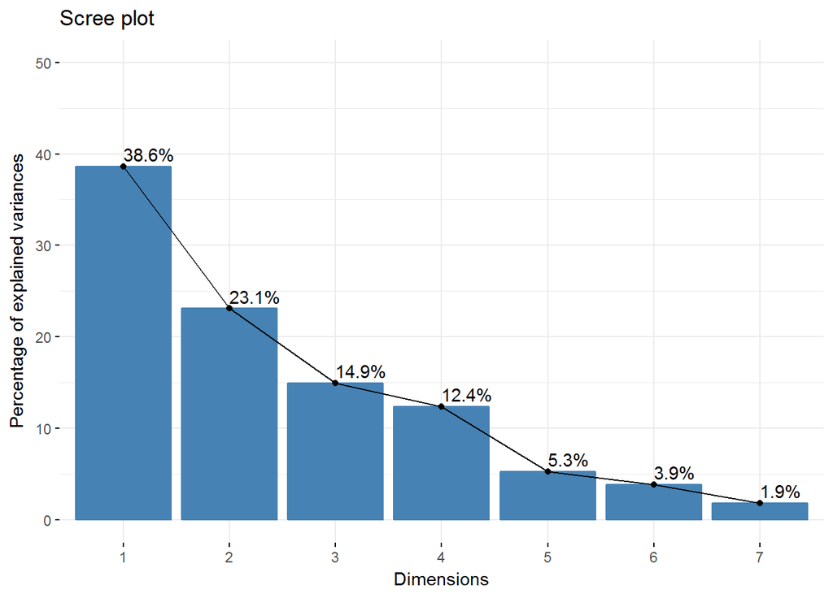

```r
fviz_eig(res_PCA, addlabels = TRUE, ylim = c(0, 50))
```

Le nombre d’axes est déterminé par le point, au-delà duquel les valeurs propres restantes sont toutes relativement petites et de tailles comparables (Jollife 2002, Peres-Neto, Jackson, and Somers (2005)).

Nous proposerons de conserver par la suite les 4 premières composantes principales qui représentent 89% de la variation.

Le premier plan factoriel, présente l’intérêt d’être facilement interprétable (dimension 2) et de résumer 61 % de l’information. Les représentations graphiques qui suivront concerneront ce plan.

### Graphiques des individus

Affichons le nuage des individus (camions) dans le premier plan factoriel, ainsi que les modalités des variables qualitatives supplémentaires :

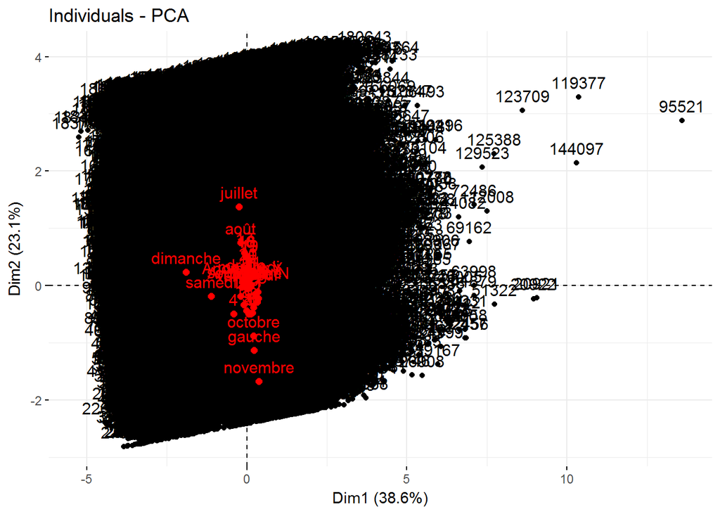

```r
# Graphique des individus
p <- fviz_pca_ind(res_PCA)
fviz_add(p,res_PCA$quali.sup$coord,color = "red")
```

Il y a trop d’individus affichés, et il est donc impossible de débusquer des groupes de camions à l’oeil nu. Cette représentation permet par contre de constater la présence d’individus se détachant par leur valeur. Ainsi, l’individu **95521** a une coordonnée très forte sur l’axe 1 et a donc des valeurs fortes par rapport aux variables qui seront fortement corrélées à cet axe. Ce type d’individu peut être un outlier ou constituer un parangon, c’est à dire un représentant fort de la classe à laquelle il appartient.

Nous allons analyser visuellement la qualité de représentation des individus (cos2) :

Un point est dit bien représenté sur un axe ou un plan factoriel si il est proche de sa projection sur l’axe ou le plan. S’il est éloigné, on dit qu’il est mal représenté. L’Indicateur est l’angle formé entre le point et sa projection sur l’axe (cos proche de 1 correspond à un individus bien representé).

Représentons les 100 individus ayant le plus contribué à la construction des deux axes du plan factoriel principal, en colorant suivant la qualité de la représentation du point :

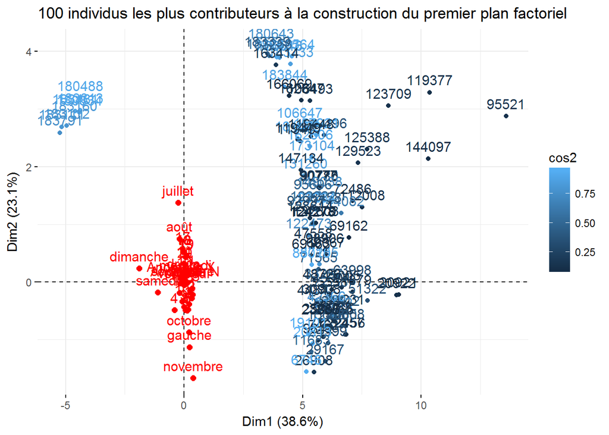

```r
# Graphique des 100 individus les plus contributeurs suivant leur qualite de representation
p<- fviz_pca_ind(res_PCA, col.ind = "cos2", select.ind = list(contrib= 100)) +
               labs(title ="100 individus les plus contributeurs à la construction du premier plan factoriel")
fviz_add(p,res_PCA$quali.sup$coord,color = "red")
```

Nous remarquons à l’aide de cette représentation visuelle, les points bien représentés (en bleu clair) et ceux dont la qualité de la représentation est moindre (bleu foncé), parmi les individus contribuant le plus à la construction des axes.

Nous proposons une représentation visuelle, des 100 individus contribuant le plus à la construction du premier plan principal, en les colorant suivant si une anomalie a été déclenchée ou non durant leur passage :

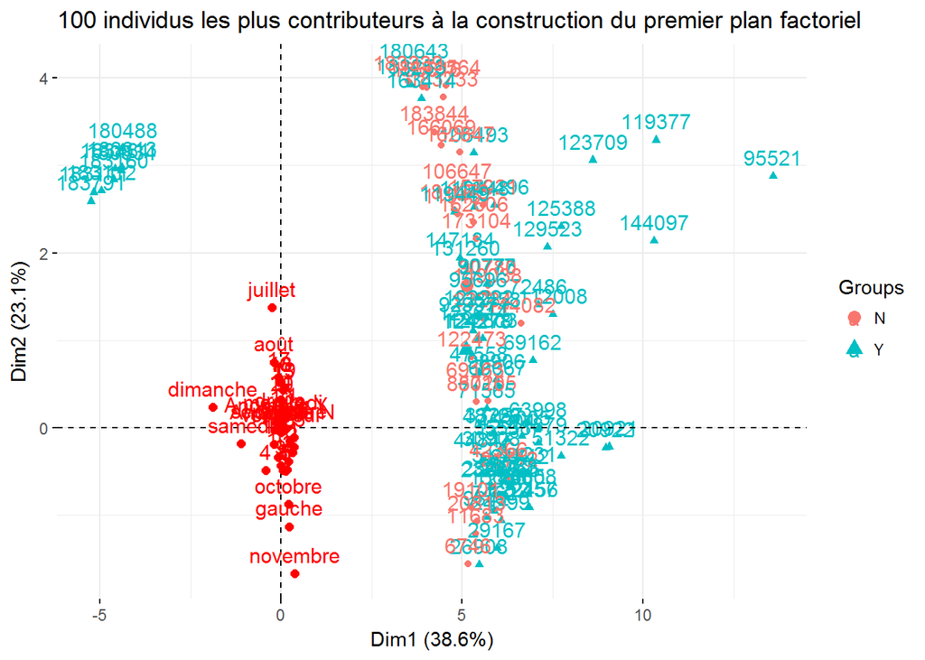

```r
# Graphique des 100 individus les plus contributeurs avec coloration suivant la modalité de la variable Anomalie
p <- fviz_pca_ind(res_PCA, select.ind = list(contrib= 100), habillage = siwim_final$Anomalie) +
  labs(title ="100 individus les plus contributeurs à la construction du premier plan factoriel")
fviz_add(p,res_PCA$quali.sup$coord,color = "red")
```

Le résultat visuel est étonnant : alors que seul 1 camion sur trois fait l’objet d’une anomalie déclenchée par le système de pesage, nous voyons clairement que la majorité des contributeurs aux axes sont des camions ayant déclenché une Anomalie. Ceci parait potentiellement cohérent avec les éventuelles valeurs fortes que prendraient ces camions par rapport à certaines valeurs physiques (surpoids).

### Graphique des variables

Nous allons visualiser les variables et formuler des conclusions concernant leur corrélation. Nous étudierons la qualité de leur représentation et leur contribution aux composantes principales.

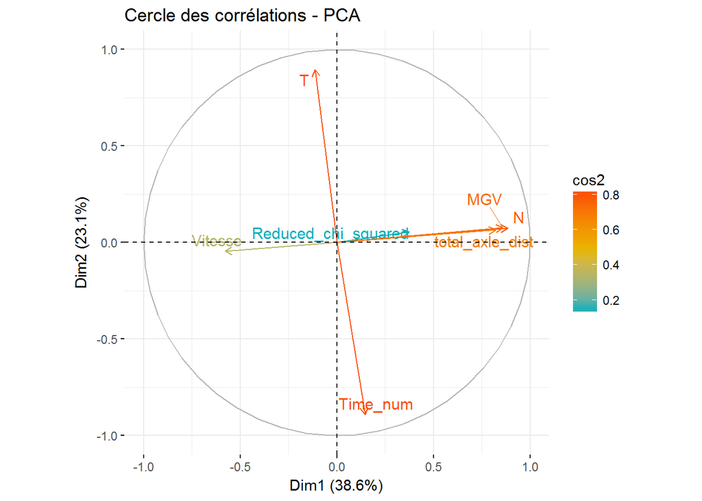

```r
# Cercle des correlations coloré en fonction de la qualité de représentation
fviz_pca_var(res_PCA, col.var = "cos2",
             gradient.cols = c("#00AFBB", "#E7B800", "#FC4E07"),
             repel = TRUE # Évite le chevauchement de texte
             ) + labs(title ="Cercle des corrélations - PCA")
```

Ce graphique montre les relations entre les variables qui sont regroupées quand elles sont corrélées.

Ici `N`(nombre d’essieux), `MGV`(masse du camion),`total_axle_dist` (distance totale entre les essieux les plus distants) sont fortement corrélés à la fois entre elles et à l’axe 1. Ces trois variables sont corrélées négativement à `Vitesse`.

**Le premier axe oppose les camions les plus volumineux (car nombre d’essieux importants, masse importante, et longueur importante) au camion les plus petits, les moins lourds et qui sont les plus rapides.**

**Le deuxième axe montre que la température `T` est corrélée négativement à la variable `Time_Num` qui est la variable de temps (continue).** `Time_num` est la variable numérique du temps : ici on montre que plus `Time_num` est importante, plus la température est basse. Ce qui est logique car la prise de mesure s’est déroulée entre depuis de l’Eté à l’hiver.

### Contributions des variables aux axes principaux

```r
# Contribution des variables
res_PCA$var$contrib
```

```
##                          Dim.1      Dim.2        Dim.3       Dim.4
## N                   28.9034034  0.3462610 1.275661e+01  0.09612741
## total_axle_dist     25.0132931  0.2578010 2.138125e+01  2.15091595
## T                    0.4625367 49.6935066 9.634309e-03  0.02270671
## Reduced_chi_squared  5.1832674  0.1787933 2.170693e+01 72.66629917
## Time_num             0.7907425 49.0437286 4.474765e-04  0.12976510
## Vitesse             12.3938563  0.1274456 4.113615e+01 18.09642235
## MGV                 27.2529005  0.3524639 3.008981e+00  6.83776331
##                            Dim.5        Dim.6        Dim.7
## N                   3.821488e-02 2.731575e+00 55.127809544
## total_axle_dist     4.984609e-03 7.942747e+00 43.249008684
## T                   4.980743e+01 3.496282e-04  0.003832712
## Reduced_chi_squared 1.034711e-01 9.238145e-02  0.068859230
## Time_num            5.002207e+01 2.510093e-03  0.010740476
## Vitesse             2.339904e-02 2.798455e+01  0.238179617
## MGV                 4.312881e-04 6.124589e+01  1.301569737
```

Plus la valeur de la contribution est importante, plus la variable contribue à la composante principale en question. Ainsi `N`, `total_axle_dist`, `MGV` contribuent le plus fortement à l’axe 1. `T` et `Time_num` expliquent à elle deux la variabilité de l’axe 2.

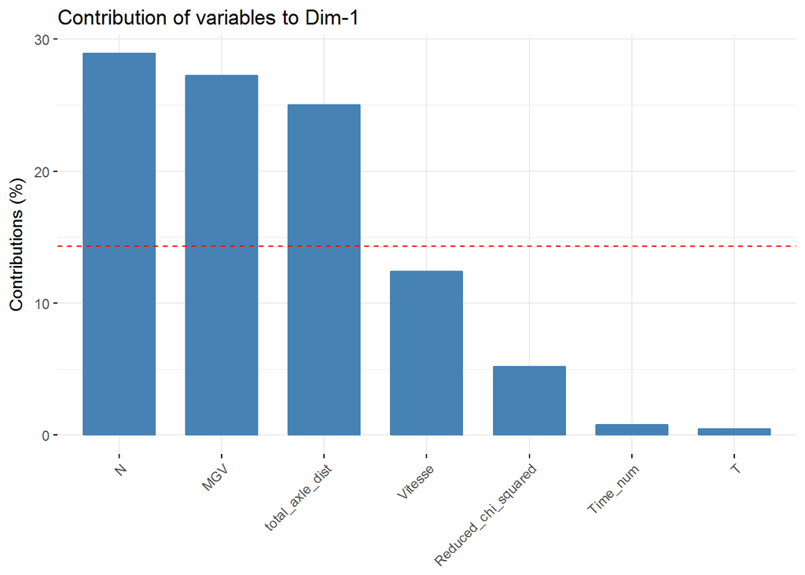

```r
# Contributions des variables à composante 1
fviz_contrib(res_PCA, choice = "var", axes = 1)
```

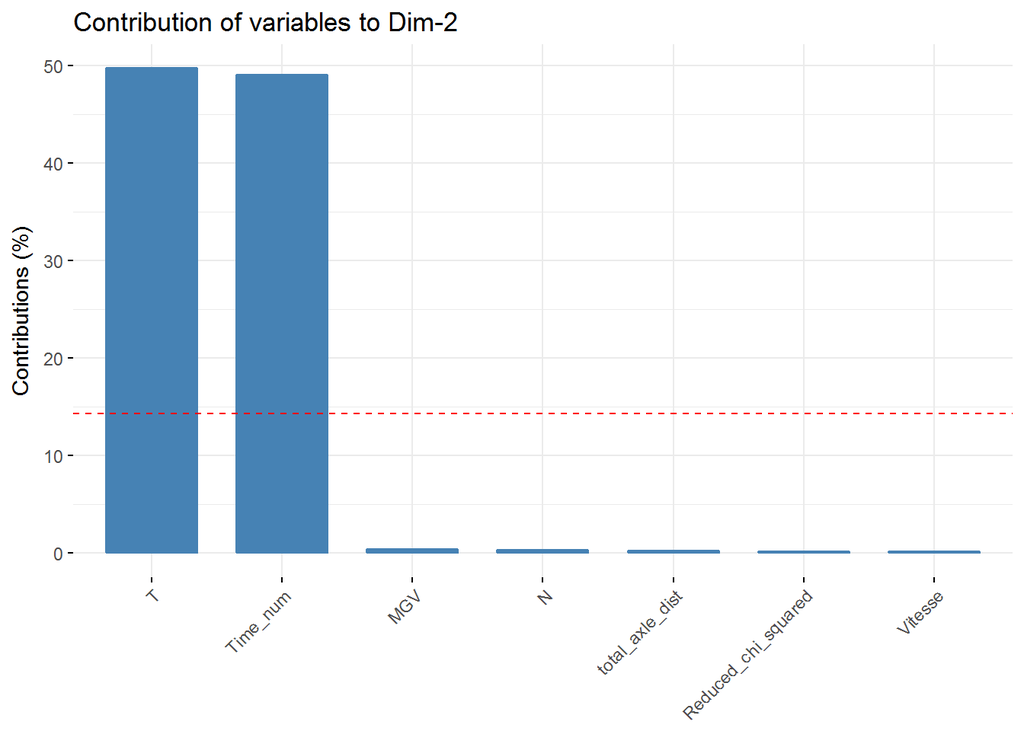

```r
# Contributions des variables à composante 2
fviz_contrib(res_PCA, choice = "var", axes = 2)
```

```r
# Qualite de representation des variables
res_PCA$var$cos2
```

```
##                          Dim.1       Dim.2        Dim.3        Dim.4
## N                   0.78117344 0.005599296 1.334447e-01 0.0008323809
## total_axle_dist     0.67603527 0.004168833 2.236657e-01 0.0186250860
## T                   0.01250100 0.803580617 1.007829e-04 0.0001966206
## Reduced_chi_squared 0.14008837 0.002891219 2.270725e-01 0.6292277815
## Time_num            0.02137143 0.793073227 4.680976e-06 0.0011236544
## Vitesse             0.33496925 0.002060890 4.303183e-01 0.1566994854
## MGV                 0.73656523 0.005699600 3.147644e-02 0.0592091614
##                            Dim.5        Dim.6        Dim.7
## N                   1.408791e-04 7.375141e-03 7.143413e-02
## total_axle_dist     1.837576e-05 2.144509e-02 5.604168e-02
## T                   1.836151e-01 9.439820e-07 4.966394e-06
## Reduced_chi_squared 3.814460e-04 2.494262e-04 8.922718e-05
## Time_num            1.844063e-01 6.777150e-06 1.391741e-05
## Vitesse             8.626055e-05 7.555714e-02 3.086310e-04
## MGV                 1.589943e-06 1.653614e-01 1.686563e-03
```

la qualité de représentation (le cos2) est très bonne pour `N`et `total_axle_dist` et `MGV`. `Vitesse` n’a pas une représentation excellente Sur l’axe 2, `T` et `Time_Num` sont très bien représentées.

### Description des dimensions

Nous avons decrit précédemment les axes constituant les deux dimensions du plan principal.

La fonction suivante est utilisée pour identifier les variables les plus significativement associées à une composante principale.

```r
dimdesc(res_PCA, axes = c(1,2), proba = 0.05)
```

```
## $Dim.1
## $Dim.1$quanti
##                     correlation p.value
## N                     0.8838402       0
## MGV                   0.8582338       0
## total_axle_dist       0.8222136       0
## Reduced_chi_squared   0.3742838       0
## Time_num              0.1461897       0
## T                    -0.1118079       0
## Vitesse              -0.5787653       0
##
## $Dim.1$quali
##                       R2       p.value
## Mois_annee   0.022102137  0.000000e+00
## Jour_semaine 0.040239988  0.000000e+00
## Heure        0.005331577 5.027596e-193
## Anomalie     0.003141757 6.983194e-128
## Lane         0.001842100  9.912468e-76
##
## $Dim.1$category
##               Estimate       p.value
## novembre   0.364298109  0.000000e+00
## octobre    0.194095976 1.458366e-140
## N          0.101570475 6.983194e-128
## gauche     0.124769710  9.912468e-76
## jeudi      0.511345771  6.684610e-70
## 7          0.091366846  2.220234e-26
## mardi      0.459070696  6.573980e-24
## 6          0.114432825  2.851236e-21
## lundi      0.452212329  1.388854e-18
## mercredi   0.431721041  1.114275e-12
## 23         0.290038615  3.343627e-12
## 2          0.260659147  2.208185e-11
## 1          0.299377768  2.335474e-11
## 3          0.143399424  2.972301e-07
## 5          0.062666133  1.389205e-06
## 0          0.193853552  1.897463e-06
## 21         0.093510370  1.478139e-05
## 19         0.025048590  1.741425e-04
## 16        -0.097745634  3.968270e-03
```

[output cut: 60 more lines]

```
## vendredi  -0.06378894  2.702400e-18
## samedi    -0.18844663  9.425203e-27
## N         -0.03932248  2.362212e-33
## 3         -0.33476296  9.690513e-37
## 11        -0.13989458  1.034302e-67
## 4         -0.44167347  1.567997e-76
## 5         -0.44496467 6.421518e-145
## 10        -0.28669662 1.150436e-222
## 6         -0.42880255 4.422177e-254
## gauche    -0.61945059  0.000000e+00
## 9         -0.38617165  0.000000e+00
## 8         -0.43977155  0.000000e+00
## 7         -0.43196366  0.000000e+00
## octobre   -0.78690484  0.000000e+00
## novembre  -1.58528132  0.000000e+00
```

La fonction de description `dimdesc` permet de mettre en évidence la relation des variables qualitatives supplémentaires (ainsi que leur modalité) avec les axes factoriels. Nous avons vu précédement dans les affichage graphiques, que le nuage des modalités des variables qualitatives se “concentrait” au centre du plan. Les variables qualitatives sont certes liées aux axes, mais possèdent des coordonnées ne prenant pas de valeurs significativement hautes ou basses, ce qui empêche de tirer des conclusions.

Nous observons à titre d’exemple que la modalité `N` de la variable `Anomalie` a une coordonnée positive sur l’axe 1 (inversement pour la modalité `Y`) ce qui pourrait s’interpréter de la façon suivante : “les camions prenant des valeurs positives sur l’axe 1 ont tendance à ne pas déclencher d’anomalie”. Nous rappelons que les camions prenant des valeur positives sur cet axe semblent être les plus volumineux.

Concernant l’axe 2, il est beaucoup plus net que la variable `Mois_annee` soit bien représentée. Ses modalités ont des coordonnées plus fortes en valeur absolue, discriminant le groupe de modalité `octobre, novembre` avec celui `Juillet, Aout`. Rappelons que cet axe discrimine les camions enregistrés lors d’une prise de température forte en opposition à ceux enregistrés lors d’une prise de température faible du système.

# Clustering (apprentissage non supervisé)

Nous avons vu précédemment que suite à l’ACP, les 4 premières composantes principales expliquaient 89 % de la variabilité. Nous réduisons donc notre nuage de point en effectuant une nouvelle ACP en ne conservant que les 4 premières variables.

Chaque algorithme de clustering sera exécuté sur ce nouvel ensemble.

```r
# On réalise un prétraitement par ACP normée en gardant 4 dimensions
res_PCA2 <- PCA(varquanti2, scale.unit = TRUE, graph = FALSE,ncp = 4)

# On stocke les 4 premieres composantes principales dans un data frame
don_PCA_clusters <- data.frame(res_PCA2$ind$coord)
```

Chaque méthode testée produira ses clusters, qui seront stockés dans le data frame contenant les coordonnées des axes factoriels, afin de faciliter les comparaisons et représentations ultérieures.

## Méthode hiérarchique :

Les méthodes hiérarchiques présentent l’intérêt de proposer un nombre optimal de cluster, dont le découpage est réalisé en optimisant un critère.

### kmeans + CAH sur composantes principales

Notre jeu de donnée contient plusieurs centaines de milliers d’individus. Nous allons donc être exposés à des problèmes calculatoires et de mémoire.

Afin de contourner cette difficulté, nous allons réaliser en amont un partitionnement à l’aide des Kmeans. Nous fixons un nombre de partitions grand, avec pour objectif d’obtenir pour chacune une faible inertie intra-classe (homogéneité).

On met ensuite en oeuvre une classification ascendante hiérarchique (CAH) sur ces groupes d’individus issus de l’étape précédente et on obtient une hiérarchie qui est approximativement la haut de la hiérarchie que l’on obtiendrait en classifiant les individus directement.

```r
# Kmeans sur un nombre grand nombre de clusters
set.seed(123)
res_kmeans_grand <- kmeans(don_PCA_clusters[,c("Dim.1","Dim.2","Dim.3","Dim.4")],centers=1000,iter=100)
```

On effectue ensuite une CAH sur les centres des classes :

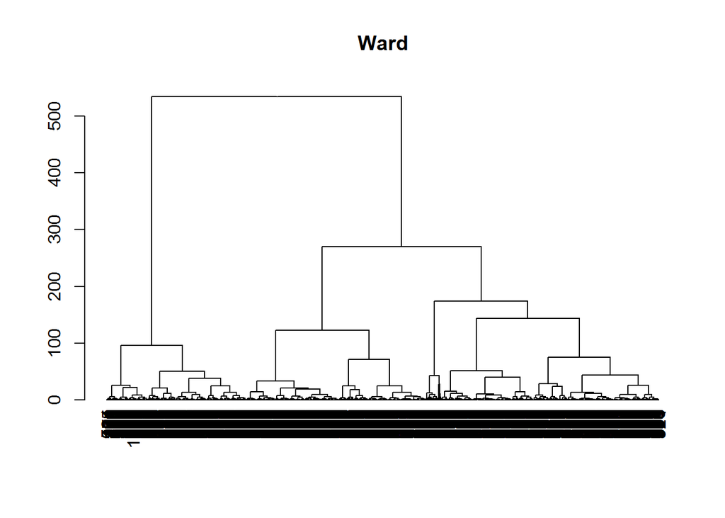

```r
# Calcul de la matrice de distance (euclidienne)
dist <- dist(res_kmeans_grand$centers,method="euclidean")

# Classification Ascendante Hierarchique (methode de Ward)
cah <- fastcluster::hclust(dist,method="ward.D")

# Affichage dendrogramme
plot(as.dendrogram(cah),main="Ward")
```

3 ou 4 groupes semblent se détacher.

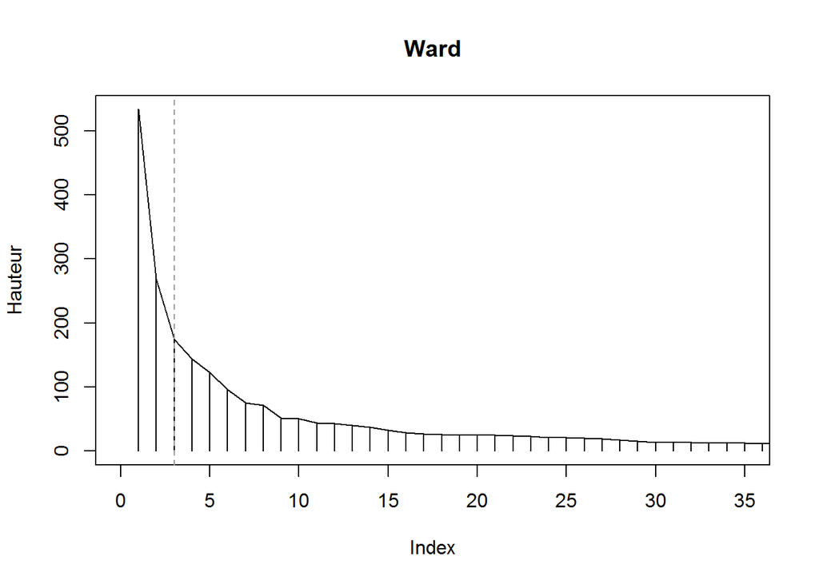

```r
# Recherche du nombre de classe
plot(sort(cah$height,decreasing=TRUE),xlim=c(0,35),type="h",ylab="Hauteur",main="Ward")
lines(sort(cah$height,decreasing=TRUE),xlim=c(0,35))
abline(v=3, lty=2, col='gray60')
```

Un niveau de coupure à 3 ou 4 classes semble être envisageable.

Nous décidons de couper à 3 classes:

```r
# On décide du niveau de coupure
classes_centres <- cutree(cah,k=3)

# Nous rajoutons la variable de classe au jeu de données contenant les axes factoriels
don_PCA_clusters$clusters_cah_mixte <- as.factor(classes_centres[res_kmeans_grand$cluster])
```

Représentons sur le premier axe factoriels, les individus colorés en fonction de leur groupe déterminés par la CAH mixte.

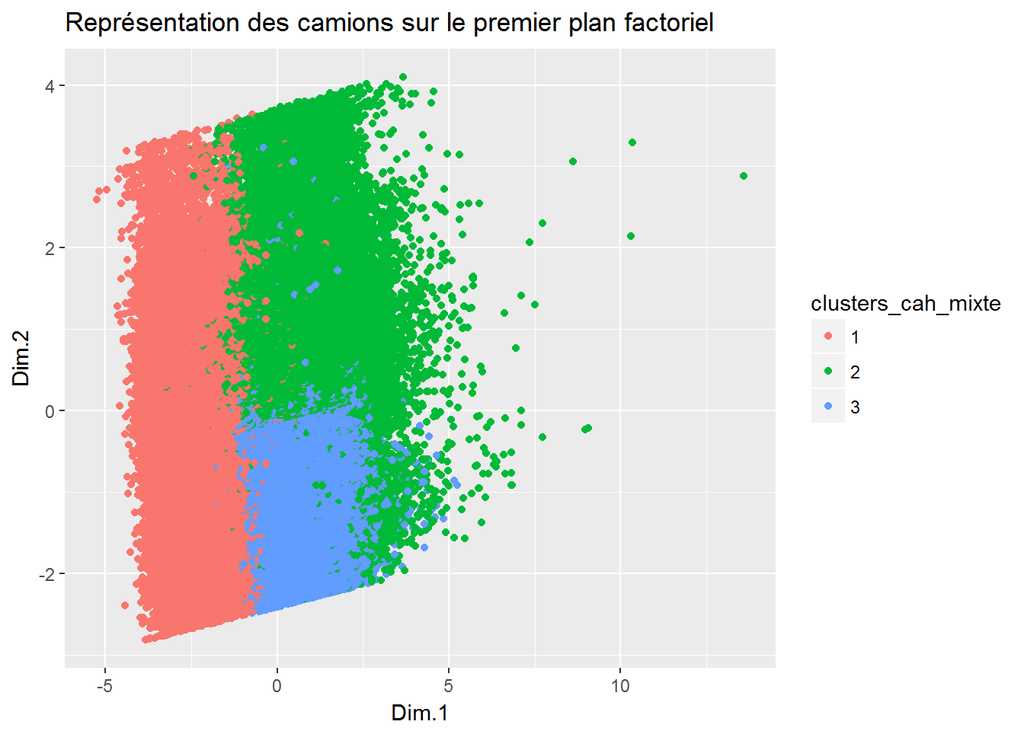

```r
# Affichage sur le premier plan principal des individus en fonction de leur groupes
ggplot(don_PCA_clusters, aes(x=Dim.1, y=Dim.2, color=clusters_cah_mixte)) + geom_point() +
    labs(title ="Représentation des camions sur le premier plan factoriel")
```

## Partitionnement : K-means sur composantes principales

```r
# kmeans sur 3 groupes
set.seed(123)
res_kmeans <- kmeans(don_PCA_clusters[,c("Dim.1","Dim.2","Dim.3","Dim.4")],centers=3,iter=500)

# Nous rajoutons la variable de classe au jeu de données contenant les axes factoriels
don_PCA_clusters$clusters_kmeans <- as.factor(res_kmeans$cluster)
```

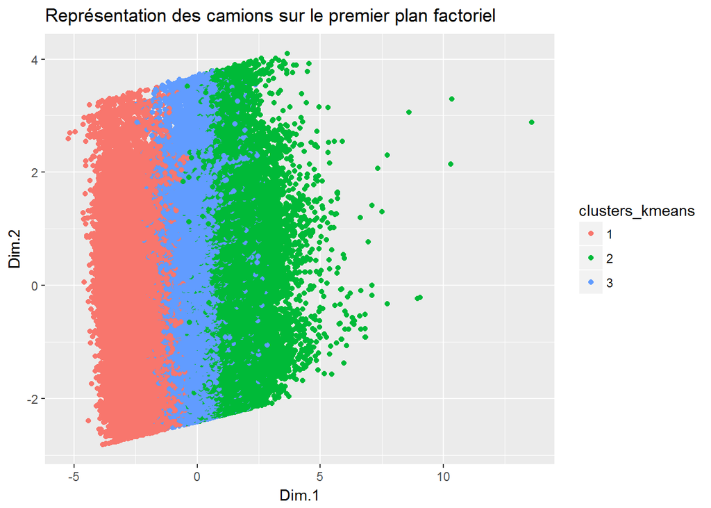

```r
# Affichage sur le premier plan principal des individus en fonction de leur groupes
ggplot(don_PCA_clusters, aes(x=Dim.1, y=Dim.2, color=clusters_kmeans)) + geom_point() +
    labs(title ="Représentation des camions sur le premier plan factoriel")
```

## Partitionnement k - medoides : CLARA sur composantes principales

Un medoïde est le représentant le plus central d’une classe. L’algorithme des k-medoïdes réalise un partitionnement plus robuste vis à vis des données aberrantes, que celui des k-means.

Il s’agit d’un extension aux méthodes k-medoides pour traiter de grands jeux de données (plusieurs milliers d’observations). Elle est donc adaptée à notre contexte :

```r
# On applique la méthode CLARA sur 3 groupes
set.seed(123)
res_clara <- clara(don_PCA_clusters[,c("Dim.1","Dim.2","Dim.3","Dim.4")],k = 3)

# Nous rajoutons la variable de classe au jeu de données contenant les axes factoriels
don_PCA_clusters$clusters_clara <- as.factor(res_clara$clustering)
```

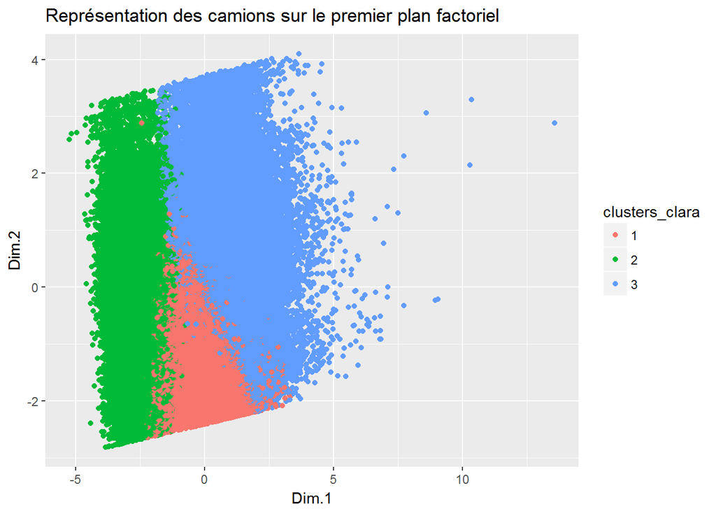

```r
# Affichage sur le premier plan principal des individus en fonction de leur groupes
ggplot(don_PCA_clusters, aes(x=Dim.1, y=Dim.2, color=clusters_clara)) + geom_point() +
    labs(title ="Représentation des camions sur le premier plan factoriel")
```

## Partitionnement k - medoides : PAM sur composantes principales

PAM (Partitioning Around Medoid) est une implémentation populaire mais nécessite de calculer les distances entre chaque individus pris deux à deux et pénalise ainsi la scalabilité que nous rencontrons dans notre cas.

## Partitionnement basé sur densité : DBSCAN sur composantes principales

DBSCAN est un algorithme de partitionnement de type “densité”. Il s’appuie sur la densité des données pour réaliser le partitionnement. L’algorithme utilise deux parametres : la distance epsilon et le nombre de points minimum devant se trouver dans un rayon epsilon pour considerer ces points comme un cluster.

Afin de déterminer la valeur optimale d’epsilon, nous utilisons les distances des k plus proches voisins d’une matrice de points.L’idée est de calculer la moyenne des distances de chaque point à ces k plus proches voisins. La valeur de k sera spécifiée par l’utilisateur et correspond au nombre de points minimum (nous choisissons k = nombre dimension du data set + 1). Ensuite les k-distances sont affichés graphiquement dans l’ordre croissant. Le but est de trouver le “genou” correspondant au paramètre optimal epsilon.

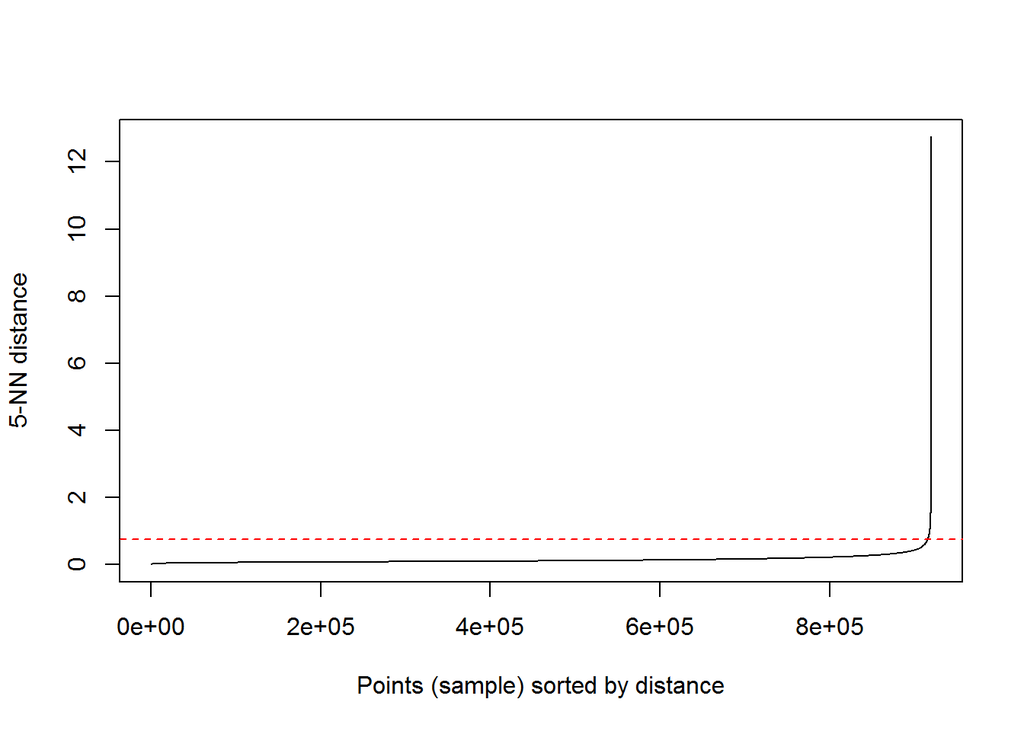

```r
# Determination de la valeur epsilon optimale, k = nombre de dimension + 1
dbscan::kNNdistplot(don_PCA_clusters[,c("Dim.1","Dim.2","Dim.3","Dim.4")], k =  5)
abline(h=0.75, col = "red", lty=2)
```

Nous executons ensuite DBSCAN avec les paramètres eps et minPts de l’heuristique précédente.

```r
# DBSCAN
set.seed(123)
res_dbscan <- dbscan::dbscan(don_PCA_clusters[,c("Dim.1","Dim.2","Dim.3","Dim.4")], eps = 0.75, minPts = 5)

# Nous rajoutons la variable de classe au jeu de données contenant les axes factoriels
don_PCA_clusters$clusters_dbscan <- as.factor(res_dbscan$cluster)
```

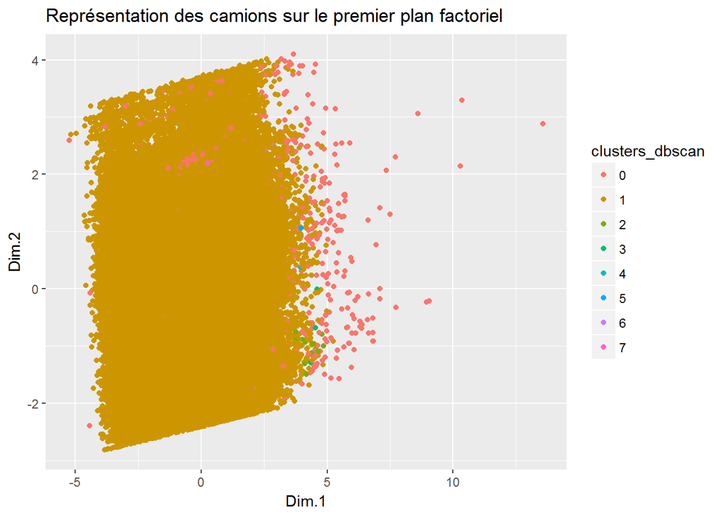

```r
# Affichage sur le premier plan principal des individus en fonction de leur groupes
ggplot(don_PCA_clusters, aes(x=Dim.1, y=Dim.2, color=clusters_dbscan)) + geom_point() +
    labs(title ="Représentation des camions sur le premier plan factoriel")
```

L’algorithme propose ici 7 clusters. Nous essaierons néanmoins d’interpréter les clusters (voir ci après)

## Partitionnement basé sur densité : OPTICS sur composantes principales

Cet algorithme est similaire à DBSCAN et élimine son principal défaut : l’impossibilité de détecter des partitions de densités différentes.

## Méthodes neuronales : cartes auto-adaptatives de Kohonen (SOM)

Les cartes de Kohonen forment une classe de neurones artificiels, formant une méthode d’apprentissage non supervisé. L’algorithme est très léger en temps de calcul, permet de détecter des relations non linéaires mais présente l’inconvénient que les relations entre neurones ne peuvent être cassées pour une meilleure représentation des données. L’algorithme “Growing Neural Gas” corrige ce problème.

## Interprétation des classes

Nous interpretons les classes construites dans chaque méthode. L’idée est de dégager une interprétation commune, favorisant l’utilité métier.

Mais avant cela, nous rajoutons au jeu de données quantitatives initiales, les classes : construite via chacune des méthodes :

```r
# Rajout des classes dans le jeu de variables quanti (pour l'interprétation) et d'analyse final
varquanti_clusters <- cbind.data.frame(varquanti2,don_PCA_clusters[,c("clusters_cah_mixte","clusters_kmeans","clusters_clara","clusters_dbscan")])
siwim_final2 <- cbind.data.frame(siwim_final,don_PCA_clusters[,c("clusters_cah_mixte","clusters_kmeans","clusters_clara")])
```

L’interprétation des classes est réalisée en comparant la moyenne de chaque variable quantitatives de chaque classe, à la moyenne de la population globale de cette même variable :

```r
# Interpretation des classes
print("moyenne sur l'ensemble des camions")
```

```
## [1] "moyenne sur l'ensemble des camions"
```

```r
colMeans(varquanti_clusters[,.(N,total_axle_dist,T,Reduced_chi_squared,Time_num,Vitesse,MGV)])
```

```
##                   N     total_axle_dist                   T
##           4.2400074          10.6735988          19.2365270
## Reduced_chi_squared            Time_num             Vitesse
##         475.5188846           0.7071143          70.1151946
##                 MGV
##          21.3158133
```

```r
by(varquanti_clusters[,.(N,total_axle_dist,T,Reduced_chi_squared,Time_num,Vitesse,MGV)],
   varquanti_clusters$clusters_kmeans, colMeans)
```

```
## varquanti_clusters$clusters_kmeans: 1
##                   N     total_axle_dist                   T
##           2.2366974           4.9641752          19.8528186
## Reduced_chi_squared            Time_num             Vitesse
##         198.9439394           0.6898567          75.0769550
##                 MGV
##           8.4934207
## --------------------------------------------------------
## varquanti_clusters$clusters_kmeans: 2
##                   N     total_axle_dist                   T
##           4.9621230          12.2133073          18.5176213
## Reduced_chi_squared            Time_num             Vitesse
##         771.7104179           0.7216144          59.7599806
##                 MGV
##          31.9724992
## --------------------------------------------------------
## varquanti_clusters$clusters_kmeans: 3
##                   N     total_axle_dist                   T
##           4.6652005          12.4220533          19.6200541
## Reduced_chi_squared            Time_num             Vitesse
##         330.7713902           0.7022048          77.9318735
##                 MGV
##          17.7890821
```

```r
by(varquanti_clusters[,.(N,total_axle_dist,T,Reduced_chi_squared,Time_num,Vitesse,MGV)],
   varquanti_clusters$clusters_cah_mixte, colMeans)
```

```
## varquanti_clusters$clusters_cah_mixte: 1
##                   N     total_axle_dist                   T
##           2.3746552           5.4379838          19.9021718
## Reduced_chi_squared            Time_num             Vitesse
##         197.6626694           0.6902546          74.9233344
##                 MGV
##           9.3453982
## --------------------------------------------------------
## varquanti_clusters$clusters_cah_mixte: 2
##                   N     total_axle_dist                   T
##           4.9112777          12.4972610          23.5701359
## Reduced_chi_squared            Time_num             Vitesse
##         618.3181156           0.6222218          68.4176037
##                 MGV
##          25.4450063
## --------------------------------------------------------
## varquanti_clusters$clusters_cah_mixte: 3
##                   N     total_axle_dist                   T
##           4.7835231          12.2694630          13.7202516
## Reduced_chi_squared            Time_num             Vitesse
##         506.6568359           0.8178874          68.6761944
##                 MGV
##          25.0114387
```

```r
by(varquanti_clusters[,.(N,total_axle_dist,T,Reduced_chi_squared,Time_num,Vitesse,MGV)],
   varquanti_clusters$clusters_clara, colMeans)
```

```
## varquanti_clusters$clusters_clara: 1
##                   N     total_axle_dist                   T
##           4.5565152          12.0663149          13.3963913
## Reduced_chi_squared            Time_num             Vitesse
##         351.9702060           0.8169768          76.3167106
##                 MGV
##          18.5534179
## --------------------------------------------------------
## varquanti_clusters$clusters_clara: 2
##                   N     total_axle_dist                   T
##           2.1768033           4.8060669          20.2729450
## Reduced_chi_squared            Time_num             Vitesse
##         188.9694578           0.6818439          75.5223860
##                 MGV
##           7.9299071
## --------------------------------------------------------
## varquanti_clusters$clusters_clara: 3
##                   N     total_axle_dist                   T
##           4.8832659          12.2815070          21.4673694
## Reduced_chi_squared            Time_num             Vitesse
##         640.1615166           0.6673467          65.2685492
##                 MGV
##          27.6542130
```

De manière générale, nous accordons de l’importance à l’interprétabilité des classes. Nous privilégerons ainsi une partition la facilitant.

Nous choisissons de conserver la partition en trois groupes, réalisés via Kmeans sur les 4 premiers axes de l’analyse en composantes principales.

**Le groupe 1** correspond au camion ayant une longueur, un nombre d’essieux, une masse nettement inférieure à la moyenne, dont la vitesse est en moyenne supérieure. **Ce groupe comprend notamment les véhicules utilitaires légers (VUL)** notamment caractérisés par leurs deux axes

**Le groupe 2** correspond à des véhicules comportant un nombre d’essieux, une longueur, et une masse supérieures à la moyenne. La Masse est nettement plus importante, ce groupe caractérise les véhicules les plus lourds et les plus lents comme en attestent leur masse et leur vitesse moyenne.

## Rajout d’une variable de classe au jeu de donnée principal + export

```r
# Rajout variable
siwim_data_after_input_clusters <- cbind.data.frame(siwim_imputed,clusters_kmeans = don_PCA_clusters[,c("clusters_kmeans")])
```

On écrit ensuite le fichier modifié (comportant la colonne de clusters en plus dans le jeu de donné principal avec les données imputées).

```r
# Export
write.csv(siwim_data_after_input_clusters, file = "2_Data/2_Retraitees/SiWIM_data_after_input_clusters.csv")
```